# R Notebook

```r
library(tidyverse)
library(scales)
```

```r
#cbPalette <- c("#999999", "#E69F00", "#56B4E9", "#009E73", "#F0E442", "#0072B2", "#D55E00", "#CC79A7")[2:3]
cbPalette <- c("red", "blue")
```

```r
twoMixes <- Sys.glob("MitoMix/TwoPerson/2person*")
threeMixes <- Sys.glob("MitoMix/3person*")
twoOneKnown <- Sys.glob("MitoMix/TwoPerson1Known/2person*")
```

Let us quietly read 1 file…

```r
read1file <- function(file) {
 tib <- read_tsv(file, col_types=cols(), progress=FALSE)
 tib$File <- file
 return(tib)
}
```

And let’s read all of the files…

```r
lapply(twoMixes, read1file) %>% bind_rows() -> tib2
```

And do some data cleaning…

```r
separate(tib2,
         File,
         c("foo", "Population"),
         sep="\\.",
         extra='drop') %>%
  select(-foo) %>%
  filter(NComboExplain>0) -> tib # cases where the mixture could not be easily constructed and cases where two peeps have identical sequences
```

The population sizes (from the MMDIT database)

```r
tibble(Population=c("AF", "AM", "AS", "EU", "OC", "XX"),
       Count=c(3702,3292,6397,11850,1570,13833)) -> popCounts

left_join(tib, popCounts, by="Population") -> tib
```

And augment the mixture data with the sample sizes from the population

```r
tib %>% group_by(Population) %>% count() %>%
  left_join(tib, by="Population") %>%
  rename(NPairs=n) -> tib
```

Generate the plots Some of the original data simulations included OCeanians… which is a of a poor fit to the questions posed. For simplicity, that group is dropped

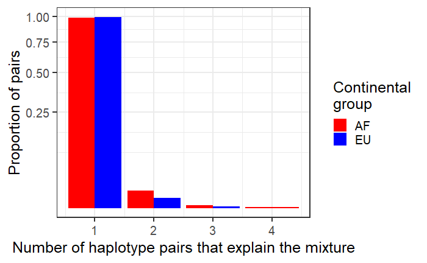

```r
tib %>%
    filter(Population != "OC") %>%
  group_by(Population, NComboExplain) %>%
  summarize(N=n(),
            Npairs=NPairs[[1]]) %>%
    ggplot(aes(y=N/Npairs, x=NComboExplain, fill=Population)) +
    geom_col(position='dodge') +
    scale_y_continuous(labels=scales::comma, trans='sqrt') +
    scale_x_continuous(breaks=1:9) +
    theme_bw(base_size=19) +
  #  viridis::scale_fill_viridis(discrete=TRUE) +
  scale_fill_manual(values = cbPalette) +
    labs(y="Proportion of pairs",
         x="Number of haplotype pairs that explain the mixture",
         fill="Continental\ngroup") -> pl
pl
ggsave("Pairs.png", pl)
```

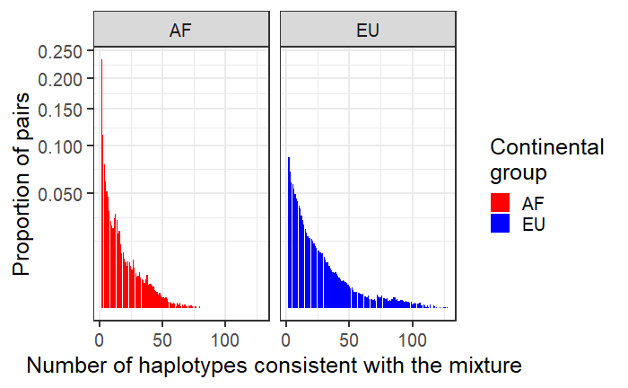

```r
tib %>%
  filter(Population != "OC") %>%
  group_by(Population, NMatch, .groups='keep') %>%
  summarize(N=n(),
            Npairs=NPairs[[1]]) %>%
    ggplot(aes(y=N/Npairs, x=NMatch, fill=Population)) +
    geom_col(position='dodge') +
    scale_y_continuous(labels=scales::comma, trans='sqrt') +
    scale_x_continuous() +
    theme_bw(base_size=19) +
  facet_wrap(~Population) +
  #  viridis::scale_fill_viridis(discrete=TRUE,begin=0.1) +
  scale_fill_manual(values = cbPalette) +
    labs(y="Proportion of pairs",
         x="Number of haplotypes consistent with the mixture",
         fill="Continental\ngroup") -> pl
pl
ggsave("PairsRMNE.png", pl)
```

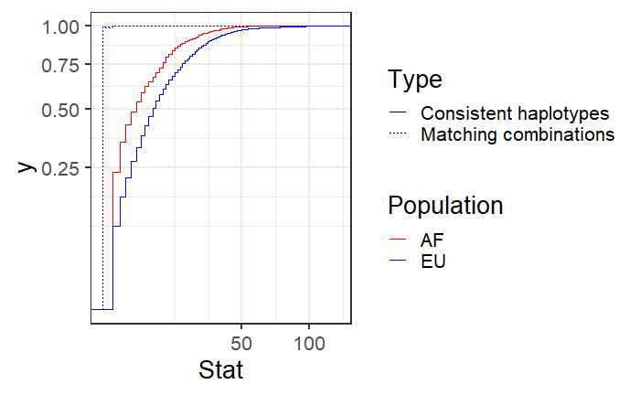

```r
bind_rows(
  select(tib, Population, NMatch) %>%
     transmute(Population=Population, Stat=NMatch, Type="Consistent haplotypes"),
  select(tib, Population, NComboExplain) %>%
     transmute(Population=Population, Stat=NComboExplain, Type="Matching combinations")
) %>%
  filter(Population != 'OC') %>%
  ggplot(aes(x=Stat, color=Population, linetype=Type)) +
  stat_ecdf() +
  scale_y_sqrt() +
  scale_x_sqrt() +
  scale_color_manual(values=cbPalette) +
  theme_bw(base_size=20)
```

```r
NA
NA
```

This was included in the first round submission. But it differed in its degrees of freedom (the likelihood of 2 individuals vs the RMNE associated with a 2-person mixture, which is similar to a single-source likelihood).

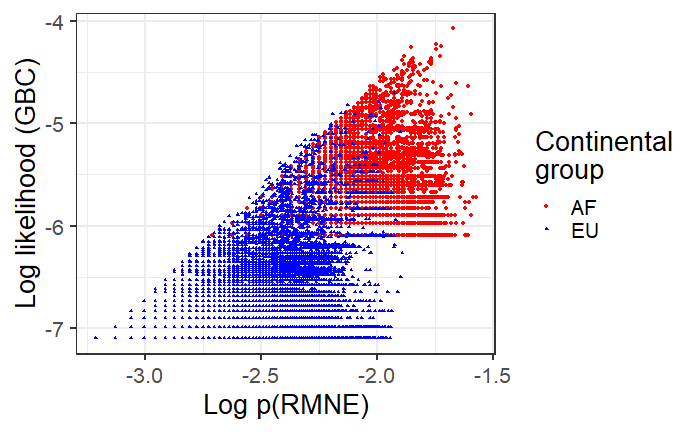

```r
tib %>% filter(Population != 'OC') %>%
ggplot(
       aes(x=RMNE, y=LogLikelihood, color=Population, shape=Population)) +
#  facet_wrap(~Population) +
  geom_point(size=0.9)+
  theme_bw(base_size=20) +
  scale_color_manual(values=cbPalette) +
    labs(x="Log p(RMNE)", y="Log likelihood (GBC)", color="Continental\ngroup", shape="Continental\ngroup") -> pl
pl

ggsave("RMNE_lr_scatterplot.png", pl, width=9, height=7)
```

```r
NA
NA
NA
```

And generate some summary statistics

```r
group_by(tib, Population) %>%
  summarize(Singletons=sum(NExplain==1),
            NComboSingle=sum(NComboExplain==1),
            Tot=n())
```

| Population | Singletons | NComboSingle | Tot |
| --- | --- | --- | --- |
| AF | 50620 | 91229 | 92009 |
| EU | 55561 | 97769 | 98035 |
| OC | 38133 | 91415 | 96861 |

```r
getmode <- function(v) {
   uniqv <- unique(v)
   uniqv[which.max(tabulate(match(v, uniqv)))]
}


group_by(tib, Population) %>%
  summarize(
    Min=min(NMatch),
    Mod=getmode(NMatch),
    Med=median(NMatch),
    Mean=mean(NMatch),
    SD=sd(NMatch),
    Mad=mad(NMatch)
    )
```

| Population | Min | Mod | Med | Mean | SD | Mad |
| --- | --- | --- | --- | --- | --- | --- |
| AF | 2 | 2 | 6 | 9.472117 | 9.460061 | 5.9304 |
| EU | 2 | 2 | 10 | 14.872954 | 14.038872 | 8.8956 |
| OC | 2 | 2 | 56 | 50.887984 | 37.503723 | 50.4084 |

And read in the likelihood/rmne information when the likleihood assessed is for 1 known and 1 unknown.

```r
tibKnown <- lapply(twoOneKnown,read1file)  %>% bind_rows()
```

Same housrkeeping as before

```r
mutate(tibKnown,
       File=basename(File)) %>%
separate(
         File,
         c("foo", "foo2", "Population"),
         sep="\\.",
         extra='drop') %>%
  select(-foo) %>%
  filter(NComboExplain>0) -> tibKnown # cases where the mixture could not be easily constructed and cases where two peeps have identical sequences
```

And also generate the final figure 11 in the paper This time don’t compare likelihoods to RMNEs that differ in their degrees of freedom ie, compare 1 known + 1 unknown (LR) vs the p(RMNE) for a 2-person mixture

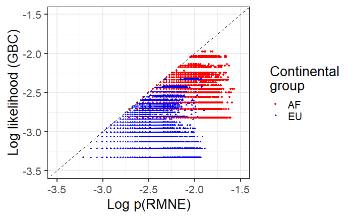

```r
tibKnown %>% filter(Population != 'OC') %>%
ggplot(
       aes(x=RMNE, y=LogLikelihood, color=Population, shape=Population)) +
#  facet_wrap(~Population) +
  geom_point(size=0.9)+
  theme_bw(base_size=20) +
  xlim(-3.5, -1.5) + ylim(-3.5, -1.5) +
  geom_abline(linetype='dashed') +
  scale_color_manual(values=cbPalette) +
    labs(x="Log p(RMNE)", y="Log likelihood (GBC)", color="Continental\ngroup", shape="Continental\ngroup") -> pl
pl

ggsave("LR1knownvsRMNE.png", pl)
```

Summary stats

```r
group_by(tibKnown, Population) %>%
  summarize(N=n(),
            MeanRMNE=mean(RMNE),
            MeanLoglike=mean(LogLikelihood ),
    Min=min(NMatch),
    Mod=getmode(NMatch),
    Med=median(NMatch),
    Mean=mean(NMatch),
    SD=sd(NMatch),
    Mad=mad(NMatch)
  )
```

| Population | N | MeanRMNE | MeanLoglike | Min | Mod | Med | Mean | SD | Mad |
| --- | --- | --- | --- | --- | --- | --- | --- | --- | --- |
| AF | 92060 | -2.416991 | -2.745730 | 2 | 2 | 6 | 9.473441 | 9.459107 | 5.9304 |
| EU | 98050 | -2.784478 | -3.253416 | 2 | 2 | 10 | 14.873626 | 14.039091 | 8.8956 |